# Complejidad Computacional Semana 2: **NP**

# **P** vs **EXPTIME**

Algoritmo de Euclides:

```
E: input: x,y
   hasta que y == 0:
       a) x ← x mod y
       b) intercambiar x y
   output x

R: input: x,y
   si E(x,y) == 1 output accept
   si no, output reject
```

- 2COLOR = {⌊*G*⌋ ∣ *G* es coloreable por $2$ colores $}$
  - $∈$ **P**
- 3COLOR = {⌊*G*⌋ ∣ *G* es coloreable por $3$ colores $}$
  - $∈$ **P**? no se sabe
  - $∈$ **EXPTIME** por cierto
  - $∈$ **TIME**(*O*(1. 3289<sup>*n*</sup>)) (Beigel y Eppstein, 2000)
- VERTEXCOVER =  
  {⌊(*G*, *k*)⌋ ∣ se puede "cubrir" el grafo *G* con *k* nodos $}$
- $∈$ **EXPTIME**
- $∈$ **P**? no se sabe

[figure not shown]

LIN(0,1) = sistemas de inecuaciónes lineales con solución booleanas

(0-1 integer programming)

LIN(0,1) $∈$ **EXPTIME** (enumerar soluciones y verificar).

no se sabe si $∈$ **P**

- formulas de lógica proposicional:  
  *φ* : : *x*<sub>*i*</sub> ∣ ¬ *φ* ∣ *φ*<sub>1</sub> ∧ *φ*<sub>2</sub> ∣ *φ*<sub>1</sub> ∨ *φ*<sub>2</sub>
- sea *x*<sub>1</sub>, …, *x*<sub>*n*</sub> la variables que aparecen en *φ*,  
  escribimos *φ*(*z*) el valor de *φ* cuando sus variables son asignadas a *z* ∈ {0, 1}<sup>*n*</sup>
- si existe tal *z*, *φ* es *satisfacible*
- SAT = {⌊*φ*⌋ ∣ *φ* satisfacible $}$
- $∈$ **EXPTIME**, no se sabe si $∈$ **P** > si ⌊*x*⌋ ∈ SAT, 3COLOR, ..., *x* es un problema que tiene una *solución*, > que es *pequeña* y *verificable rapidamente*

No es el caso de todos los lenguajes en **EXPTIME**.

# **NP**

Un lenguaje *L* ⊆ {0, 1}* está en **NP** ssi existe un polinomio *p*: ℕ ↦ ℕ y una MT M corriendo en tiempo polinomial tal que para todo *x* ∈ {0, 1}*:

*x* ∈ *L* ↔ ∃ *u* ∈ {0, 1}<sup>*p*(∣*x*∣)</sup> tal que *M*(*x*, *u*) = 1

- M se llama la *verificadora* de *L*, y *u* un *certificado* de *x* (con respeto a *L* y M).
- La definición de **NP** es asimétrica!

# Lenguajes en **NP**

existencia de certificados cortos = pertenencia a **NP**:

- SAT, LIN(0,1), 3COLOR
- traveling salesman
- subset sum
- graph isomorphism
- numeros compositos
- ...

# **P** $⊆$ **NP** $⊆$ **EXPTIME**

- **P** $⊆$ **NP**
- **NP** $⊆$ **EXPTIME**
- No se sabe si **P** ≠ **NP**, ni si **NP** ≠ **EXPTIME**.

# **P** y **NP**

- en **P** están los problemas fáciles
- en **NP** están los problemas que tienen soluciones facilmente chequeables
- **NP** representa los problemas de búsqueda con soluciones cortas

# MMTT nondeterminísticas

- Una MTND tiene *δ*<sub>0</sub> and *δ*<sub>1</sub> y un estado especial *q*<sub>*a**c**c**e**p**t*</sub>.
- En cada paso, una MTND hace una elección arbitraria entre las dos funciones de transición.
- Para un input *x*, si existe **una** secuencia de esos pasos (elecciones nondeterminísticas) que hace que M alcanza *q*<sub>*a**c**c**e**p**t*</sub>, decimos que *M*(*x*) = 1.
- Si *toda* secuencia de elecciones hace que M se detiene sin alcanzar *q*<sub>*a**c**c**e**p**t*</sub>, decimos que *M*(*x*) = 0.
- M *corre en tiempo *T*(*n*)* si para todo input *x* ∈ {0, 1}* y toda secuencia de elecciones nondeterminísticas, M alcanza *q*<sub>*h**a**l**t*</sub> o *q*<sub>*a**c**c**e**p**t*</sub> dentro de *T*(∣*x*∣) pasos.

# Observación

Una MTND *no* representa cálculos fisicamente realisables.

# Definición tradicional de **NP**

Sea *T*: ℕ ↦ ℕ y *L* ⊆ {0, 1}*. Decimos que *L* ∈ **NTIME**(*T*(*n*)) si existe una constante *c* > 0 y una TMND M en tiempo *c*⋅*T*(*n*) tal que para todo *x* ∈ {0, 1}*:  
*x* ∈ *L* ↔ *M*(*x*) = 1

*N**P*<sub>*o**l**d*</sub> = ⋃ <sub>*c* ∈ ℕ</sub>**NTIME**(*n*<sup>*c*</sup>)

# Equivalencia

Las dos definiciones son equivalentes.

1. *L* ∈ *N**P*<sub>*o**l**d*</sub> → *L* ∈ *N**P*
   - si existe una MTND M que decide *L*, se puede construir una MTD *M*ʹ que, con input (*x*, *u*) y *u* de longitud adecuada, simula una computación de *M* con input *x* eligiendo *δ*<sub>*u*[*n*]</sub> en cada paso *n*.
2. *L* ∈ *N**P* → *L* ∈ *N**P*<sub>*o**l**d*</sub>
   - se puede construir una MTND que, con input *x*, genera un certificado en *p*(∣*x*∣) pasos de manera nondeterministica, y luego lo averigua con la verificadora de *L*.

# Filología computacional

> Travelling Salesman está en **NP** porque una gira satisfaciendo *l* ≤ *k* puede ser eligida nondeterministicalmente en *n* pasos y luego la condicion *l* ≤ *k* verificada en un número polinomial de pasos [...].

> (John E. Savage, Models of Computation: Exploring the Power of Computing, 1997)

# Reducciones

Sea *A*, *B* ⊆ {0, 1}*. A es *(tiempo-)polinomialmente reducible* a *B*, denotado *A* ≤ <sub>*p*</sub>*B*, si existe una función *f*: {0, 1}* ↦ {0, 1}* calculable en tiempo polinomial tal que para todo *x* ∈ {0, 1}*, *x* ∈ *A* ssi *f*(*x*) ∈ *B*.

Proposiciones:

- si *A* ≤ <sub>*p*</sub>*B* y *B* ∈ **P** entonces *A* ∈ **P**
- ≤ <sub>*p*</sub> es transitiva

# Ejercicio

- Mostrar que 3COLOR ≤ <sub>*p*</sub> SAT:
- Proveer una traducción G → *φ*<sub>*G*</sub>
- Demostrar que: G tiene un coloreo → *φ*<sub>*G*</sub> tiene una asignación
- Demostrar que: *φ*<sub>*G*</sub> tiene una asignación → G tiene un coloreo

# **NP** hardness, completeness

Decimos que B es **NP** difícil (hard) si para todo *A* ∈ **NP**, *A* ≤ <sub>*p*</sub>*B*. Decimos que *B* es **NP** completo (complete) si *B* es **NP** difícil y está en **NP**.

Proposiciones:

- si L es **NP** difícil y L $∈$ **P**, entonces **P** = **NP**
- si L es **NP** completo, entonces L $∈$ **P** ssi **P** = **NP**.

# Un lenguaje **NP** completo

TMSAT = {⌊*M*, *x*, 1<sup>*n*</sup>, 1<sup>*t*</sup>⌋ ∣ ∃ *u* ∈ {0, 1}<sup>*n*</sup>. *M*(*x*, *u*) = 1 en t pasos$}$

- TMSAT $∈$ **NP**: la verificadora de N es una máquina universal de Turing que simula M con input (x,u) y verifica que su output es 1 despues de *t* pasos. Su corrida es polinomial en función de su input porque se puede simular máquinas con una desaceleración polinomial.
- Sea L $∈$ **NP**. Existe verificadora M corriendo en tiempo polinomial *q*(*n*), y existe un polinomio *p*(*n*) que determine el tamaño de los cartificados. Entonces a toda $x\inL$ le asociamos la string ⌊*M*, *x*, 1<sup>*p*(*n*)</sup>, 1<sup>*q*(*n* + *p*(*n*))</sup>⌋.

# **CNF-SAT**

- un literal es una variable o una variable negada (*x*<sub>*i*</sub>, ¬ *x*<sub>*i*</sub>)
- una cláusula es una disyuncción de literales tal que no aparece un literal y su contrario
- ej: *x*<sub>1</sub> ∨ ¬ *x*<sub>2</sub> ∨ ¬ *x*<sub>3</sub>
- una formula proposicional es en Forma Normal Conjunctiva si es una conjuncción de cláusulas
- ej: (*x*<sub>1</sub> ∨ *x*<sub>3</sub>) ∧ (*x*<sub>1</sub> ∨ ¬ *x*<sub>2</sub> ∨ ¬ *x*<sub>3</sub> ∨ *x*<sub>4</sub>) ∧ (¬ *x*<sub>1</sub> ∨ ¬ *x*<sub>4</sub>)
- definimos **CNF-SAT** = {⌊*φ*⌋ ∣ *φ* es en FNC y es satisfacible $}$

**SAT** ≤ <sub>*p*</sub> **CNF-SAT**

- Idea: introducir variables nuevas para evitar explosión exponencial

# **3SAT**

- una formula es en 3FNC si es en FNC y cada cláusula tiene como máximo 3 literales
- ej: (*x*<sub>1</sub> ∨ *x*<sub>3</sub>) ∧ (¬ *x*<sub>2</sub> ∨ ¬ *x*<sub>3</sub> ∨ *x*<sub>4</sub>) ∧ (¬ *x*<sub>1</sub> ∨ ¬ *x*<sub>4</sub>)
- **3SAT** = {⌊*φ*⌋ ∣ *φ* es en 3FNC y es satisfacible $}$

**CNF-SAT** ≤ <sub>*p*</sub> **3SAT**

- Idea: introducir variables nuevas para evitar explosión exponencial

# Teorema de Cook-Levin

- Cook "The Complexity of Theorem Proving Procedures", 1971
- Levin "Универсальные задачи перебора", 1973

SAT es NP-complete

# Poder expresivo booleano

- Igualdad: la formula  
  (*x*<sub>1</sub> ∨ ¬ *y*<sub>1</sub>) ∧ (¬ *x*<sub>1</sub> ∨ *y*<sub>1</sub>) ∧ … ∧ (*x*<sub>*n*</sub> ∨ ¬ *y*<sub>*n*</sub>) ∧ (¬ *x*<sub>*n*</sub> ∨ *y*<sub>*n*</sub>)  
  es satisfacible por una asignación *z* ssi *x*<sub>*i*</sub>(*z*) = *y*<sub>*i*</sub>(*z*) para todo *i*.
- Funciónes booleanas: dada *f*: {0, 1}<sup>*k*</sup> ↦ {0, 1}:
  - para *v* ∈ {0, 1}<sup>*k*</sup>, definimos *C*<sub>*v*</sub>(*x*<sub>*i*</sub>, . . , *x*<sub>*k*</sub>) una cláusula tal que *C*<sub>*v*</sub>(*v*) = 0 y *C*<sub>*v*</sub>(*u*) = 1 para *u* ≠ *v*
  - definimos *φ* = ⋀ <sub>{*v* ∣ *f*(*v*) = 0}</sub>*C*<sub>*v*</sub>(*x*<sub>1</sub>, *x*<sub>2</sub>, …, *x*<sub>*k*</sub>)
  - entonces:
    - ∀ *z* ∈ {0, 1}<sup>*k*</sup>, *φ*(*z*) = *f*(*z*)
    - ∣*φ*∣ ≤ *k*2<sup>*k*</sup>

Sea *L* ∈ **NP**, queremos mostrar que *L* ≤ <sub>*p*</sub>*S**A**T*.

Por definición, $∃$ M corriendo en tiempo polinomial y *p* polinomio tal que para todo *x* ∈ {0, 1}*:  
*x* ∈ *L* ↔ ∃ *u* ∈ {0, 1}<sup>*p*(∣*x*∣)</sup>. *M*(*x*, *u*) = 1

Queremos una transformación en tiempo polinomial *x* ↦ *φ*<sub>*x*</sub> tq:  
∃ *u* ∈ {0, 1}<sup>*p*(∣*x*∣)</sup>. *M*(*x*, *u*) = 1 ↔ *φ*<sub>*x*</sub> ∈ *S**A**T*

Reemplazamos la verificadora M por una version que:

1. tiene 2 cintas (con input en lectura sola)
2. es indiferente:
   - las corridas de M toman el mismo tiempo para todo input de tamaño *n*
   - la ubicación de los cabezales de M en un paso *i* sólo dependen del tamaño del input y de *i*

Un *instantáneo* de M es un tuple (*a*, *b*, *q*) ∈ Γ <sup>2</sup> × *Q*.

Un instantáneo puede ser representado con *c* bits, *c* dependiendo de $Γ$ y *Q* (y independiente del input).

Una *traza* es una succesión de instantáneos.

- ¿Cuales son las condiciones que debe cumplir una traza para representar una corrida exitosa de M con input (*x*, *u*)?
- Vamos a construir *φ*<sub>*x*</sub> como un patrón de traza que es satisfacible si y sólo si existe un *u* tal que *M*(*x*, *u*) = 1

A partir de la función de transición de M definimos:

- *δ*<sub>*w**r**i**t**e*</sub>: Γ <sup>2</sup> × *Q* ↦ Γ
- *δ*<sub>*s**t**a**t**e*</sub>: Γ <sup>2</sup> × *Q* ↦ *Q*

Como M es indiferente, se pueden definir las funciones $ℕ ↦ ℕ$:

- *i**n**p**o**s*(*i*) la posición del cabezal de input en el paso *i*.
- *p**r**e**v*(*i*) el último paso antes de *i* tal que el cabezal de escritura está en el mismo lugar que en el paso *i*. Definimos *p**r**e**v*(*i*) = 1 por defecto.

Los valores de *i**n**p**o**s*(*i*) and *p**r**e**v*(*i*) no dependen del input *y* = (*x*, *u*). Además esos valores pueden ser calculados en tiempo polinomial, corriendo M con un input trivial.

Restricciones que debe cumplir una traza [*z*<sub>1</sub>, *z*<sub>2</sub>, . . . , *z*<sub>*T*(*n*)</sub>] para representar una corrida exitosa de M con input *y*:

- *z*<sub>1</sub> = ( ⊳ , ⊳ , *q*<sub>*s**t**a**r**t*</sub>)
- *z*<sub>*T*(*n*)</sub> = (*a*, 1, *q*<sub>*h**a**l**t*</sub>), *a* ∈ Γ
- para todo *z*<sub>*i*</sub> = (*a*<sub>*i*</sub>, *b*<sub>*i*</sub>, *q*<sub>*i*</sub>) con *i* ∈ {2, …, *T*(*n*)}:
  - *a*<sub>*i*</sub> = *y*<sub>*i**n**p**o**s*(*i*)</sub>
  - *b*<sub>*i*</sub> = *δ*<sub>*w**r**i**t**e*</sub>(*z*<sub>*p**r**e**v*(*i*)</sub>)
  - *q*<sub>*i*</sub> = *δ*<sub>*s**t**a**t**e*</sub>(*z*<sub>*i* − 1</sub>)
- para cada *i* ∈ {2, …, *T*(*n*)}, existe une función *f* tal que esas restricciones son cumplidas ssi *f*(*y*<sub>*i**n**p**o**s*(*i*)</sub>, *z*<sub>*p**r**e**v*(*i*)</sub>, *z*<sub>*i* − 1</sub>, *z*<sub>*i*</sub>) = 1

Queremos: *φ*<sub>*x*</sub> ∈ *S**A**T* ↔ ∃ *u* ∈ {0, 1}<sup>*p*(∣*x*∣)</sup>. *y* = (*x*, *u*). *M*(*y*) = 1

Variables de *φ*<sub>*x*</sub>:

- *Y*<sub>*i*</sub> con *i* ∈ [1. . *n* + *p*(*n*)]
- *Z*<sub>*i*</sub> con *i* ∈ [1. . *c**T*(*n*)]

Codificación de las restricciónes:

- *y*[1. . *n*] = *x* → formula de tamaño 2*n*
- *z*<sub>1</sub> → formula de tamaño 2*c*
- *z*<sub>*T*(*n*)</sub> → formula de tamaño ≤ 2*c*
- para cada *i* ∈ [2. . *T*(*n*)],  
  *f*(*y*<sub>*i**n**p**o**s*(*i*)</sub>, *z*<sub>*p**r**e**v*(*i*)</sub>, *z*<sub>*i* − 1</sub>, *z*<sub>*i*</sub>) = 1  
  → formula *φ*<sub>*i*</sub> de tamaño (3*c* + 1)2<sup>3*c* + 1</sup> tal que  
  *φ*<sub>*i*</sub>(*Y*ʹ, *Z*ʹ<sub>1</sub>, *Z*ʹ<sub>2</sub>, *Z*ʹ<sub>3</sub>) = 1 ↔ *f*(. . . ) = 1  
  , con:
  - *Y*ʹ son las variables que codifican *y*<sub>*i**n**p**o**s*(*i*)</sub>
  - *Z*ʹ<sub>1</sub> son las variables que codifican *z*<sub>*p**r**e**v*(*i*)</sub>
  - *Z*ʹ<sub>2</sub> → *z*<sub>*i* − 1</sub>
  - *Z*ʹ<sub>3</sub> → *z*<sub>*i*</sub>
  - para cada *i*, para conocer *Y*ʹ, *Z*ʹ<sub>1</sub>, *Z*ʹ<sub>2</sub>, *Z*ʹ<sub>3</sub>, hay que conocer *i**n**p**o**s*(*i*) y *p**r**e**v*(*i*), y para eso hay que correr y observar *M*(0<sup>*n* + *p*(*n*)</sup>)

Tamaño de *φ*<sub>*x*</sub>:

2*n* + 2*c* + 2*c* + (*T*(*n*) − 1)(3*c* + 1)2<sup>3*c* + 1</sup> $≤$ *d*(*n* + *T*(*n*)), *d* ∈ ℕ

- se puede construir *x* ↦ *φ*<sub>*x*</sub> en tiempo polinomial:
  1. correr *M*(0<sup>*n* + *p*(*n*)</sup>)
  2. generar *φ*<sub>*x*</sub>
- *φ*<sub>*x*</sub> es en FNC
- supongamos *x* ∈ *L*  
  → ∃ *u* ∈ {0, 1}<sup>*n*</sup>. *M*(*x*, *u*) = 1  
  → existe una traza que reprensenta la corrida exitosa de *M*(*x*, *u*)  
  → usando *u* y la traza, se puede construir una asignacion *z* tal que *φ*<sub>*x*</sub>(*z*) = 1  
  → *φ*<sub>*x*</sub> ∈ CNF-SAT
- supongamos *φ*<sub>*x*</sub> ∈ CNF-SAT  
  → existe *z*, *φ*<sub>*x*</sub>(*z*) = 1  
  → constuir *u* a partir de *z*  
  → x ∈ *L*
- L ≤ <sub>*p*</sub> CNF-SAT
- Entonces CNF-SAT es **NP**-difícil
- Entonces es **NP**-completo

# Conclusiones

No tenemos ninguna demostración que **P** ≠ **NP** (≠ **EXPTIME**) pero hoy en día se supone que **NP** es más dificil que **P** (y más fácil que **EXPTIME**).

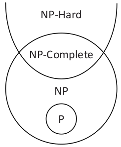